# Report - Practical Machine Learning

## Executive Summary

We built a Random Forest model using the Weight Lifting Exercises dataset, that predicts if an exercise has been performed correctly or incorrectly, on the basis of accelerometer readings. The model takes 52 features and exhibits an OOB error of around half percent and accuracy of 0.99 in the cross-validation set. This model was then used to predict the nature of the exercise for 20 observations.

## Libraries & Data Preparation

We used the following R libraries:

```r
library("caret")
library("ggplot2")
library("lubridate")
library("corrplot")
library("dplyr")
library("randomForest")
library("reshape")
```

We then downloaded two csv files containung training and test sets to our working directory. Data was provided by [Groupware@les](http://groupware.les.inf.puc-rio.br/har).

```r
# Read data
url1 <- "https://d396qusza40orc.cloudfront.net/predmachlearn/pml-training.csv"
url2 <- "https://d396qusza40orc.cloudfront.net/predmachlearn/pml-testing.csv"

download.file(url1, destfile = "training_set.csv", method="curl")
download.file(url2, destfile = "test_set.csv", method="curl")

train.dat <- read.csv(  "training_set.csv",
                        na.strings= c("NA",""," "), stringsAsFactors = FALSE)

test.dat <- read.csv( "test_set.csv",
                      na.strings= c("NA",""," "), stringsAsFactors = FALSE)
```

The outputs were stored in the `train.dat_cl` and `test.dat_cl` dataframes, the first an object of 19622 rows and 53 columns, and the second an object of 20 rows and 52 columns.

```r
# Remove columns with NAs
train.dat_NAs <- apply(train.dat, 2, function(x) { sum( is.na(x) ) })
train.dat_cl <- train.dat[, which( train.dat_NAs == 0 )]
```

```r
# Make col types of test and train sets match
types <- sapply(train.dat_cl[1,],class)
types <- as.list(types)

test.dat_cl <- convert.type(test.dat_cl, types)
```

```r
# Remove identifiers
train.dat_cl_ids <- train.dat_cl[,1:7]
train.dat_cl <- train.dat_cl[, 8:length(train.dat_cl)]
```

## Model Building & Cross-Validation

The original training set was then split into a training set and a cross validation set using `caret`'s `createDataPartition` function:

```r
# Built training set and cross-validation set
inTrain <- createDataPartition(y = train.dat_cl$classe, p = 0.7, list = FALSE)

train <- train.dat_cl[ inTrain, ]
crossval <- train.dat_cl[ -inTrain, ]
```

```r
corrMatrix <- cor( train[, -length(train)])
```

```r
modFit <- randomForest(classe ~ ., data = train, importance = TRUE)
modFit
```

```
##
## Call:
##  randomForest(formula = classe ~ ., data = train, importance = TRUE)
##                Type of random forest: classification
##                      Number of trees: 500
## No. of variables tried at each split: 7
##
##         OOB estimate of  error rate: 0.6%
## Confusion matrix:
##      A    B    C    D    E class.error
## A 3902    3    0    0    1    0.001024
## B   13 2635   10    0    0    0.008653
## C    0   16 2376    4    0    0.008347
## D    0    0   28 2223    1    0.012877
## E    0    0    1    5 2519    0.002376
```

The model obtained here (500 trees) has a very small OOB error rate of around half percent. We also get additional information regarding the importance of variables in the classification via the mean decrease in the Gini index over the activity classes; the higher this value, the more important the associated feature is. In Fig. 1 below, we show the order of importance of the features used in this model:

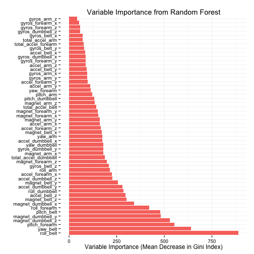

so `roll_belt` and `yaw_belt` were deemed most important when building the model.

We then proceeded to cross-validate.

```r
# Cross Validation with cv set
predictCV <- predict(modFit, crossval)
confusionMatrix(crossval$classe, predictCV)
```

```
## Confusion Matrix and Statistics
##
##           Reference
## Prediction    A    B    C    D    E
##          A 1674    0    0    0    0
##          B    2 1137    0    0    0
##          C    0    8 1011    7    0
##          D    0    0    4  958    2
##          E    0    0    0    3 1079
##
## Overall Statistics
##
##                Accuracy : 0.996
##                  95% CI : (0.994, 0.997)
##     No Information Rate : 0.285
##     P-Value [Acc > NIR] : <2e-16
##
##                   Kappa : 0.994
##  Mcnemar's Test P-Value : NA
##
## Statistics by Class:
##
##                      Class: A Class: B Class: C Class: D Class: E
## Sensitivity             0.999    0.993    0.996    0.990    0.998
## Specificity             1.000    1.000    0.997    0.999    0.999
## Pos Pred Value          1.000    0.998    0.985    0.994    0.997
## Neg Pred Value          1.000    0.998    0.999    0.998    1.000
## Prevalence              0.285    0.195    0.172    0.164    0.184
## Detection Rate          0.284    0.193    0.172    0.163    0.183
## Detection Prevalence    0.284    0.194    0.174    0.164    0.184
## Balanced Accuracy       0.999    0.996    0.996    0.994    0.999
```

The accuracy of the resulting model was of 0.99. We can also look at the margin, which is defined as the average (over all trees) of the votes for the right class minus the maximum of the average over the votes for the other classes, so higher margins imply better confidence in the prediction per class. Fig. 2, plots the margin per class via a violin plot:

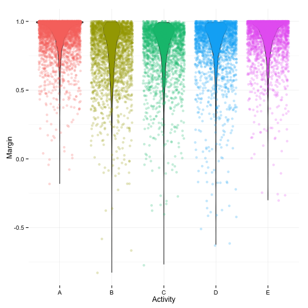

So predicting the exercise to be of class A (correct way of exercise) can be done with the outmost confidence.

## Prediction

We finally apply our model to the test set of 20 observations:

```r
# Now apply model to test set
# Remove identifiers
test.dat_cl_ids <- test.dat_cl[,1:7]
test.dat_cl <- test.dat_cl[, 8:length(test.dat_cl)]

# predict the classes of the test set
predictTest <- predict(modFit, test.dat_cl)
predictTest
```

```
##  1  2  3  4  5  6  7  8  9 10 11 12 13 14 15 16 17 18 19 20
##  B  A  B  A  A  E  D  B  A  A  B  C  B  A  E  E  A  B  B  B
## Levels: A B C D E
```

## Conclusions

The rise of devices such as Jawbone Up, Nike FuelBand, and Fitbit have made possible to collect data about personal activity in a fast and inexpensive way. This has made an impact in human activity recognition research. In particular, with the right data it is possible to differentiate between “well-performed”“ activities vs "bad-performed” ones and build models to classify outputs, which can provide useful information to fields such as high-performance sports training, etc.